# Pertemuan 3 - Anreg K1

Nabil Bintang Prayoga

2025-02-17

# Data

```r
library(readxl)
dt <- read_xlsx("D:\\KULIAHH\\SEMESTER 6\\ASPRAK ANREG\\Pertemuan 2\\Data Bintang.xlsx")
dt
```

```
## # A tibble: 22 × 14
##    Wilayah      PPM   IPM   RLS     JP   PBH   TBS   ASL   TPT  PDRB   JSM   UHH
##    <chr>      <dbl> <dbl> <dbl>  <dbl> <dbl> <dbl> <dbl> <dbl> <dbl> <dbl> <dbl>
##  1 Sumba Bar…  27.2  65.2  6.92 152414 11.9   0.39  58.8  3.52 10199 12696  67.6
##  2 Sumba Tim…  28.1  67.0  7.57 255498  5.87  0.3   61.8  2.21 16617 36053  65.8
##  3 Kupang      21.8  65.8  7.42 376837  6.17  1.18  76.4  3.22 13793 59622  65.6
##  4 Timor Ten…  25.2  63.6  6.97 474521  7.71  1.03  67.9  2.64 10953 57201  66.9
##  5 Timor Ten…  21.8  65.2  8.16 271277  3.98  0.45  80.6  1.96 11511 42634  67.6
##  6 Belu        14.3  63.8  7.39 231008  6.34  0.71  84.0  5.45 13997 45693  65.6
##  7 Alor        20.0  63.0  8.45 221536  1.75  0.63  81.6  2.52  9900 22483  62.4
##  8 Lembata     24.8  66.1  8.26 141391  3.95  1.2   87.4  2.55  8767 21220  67.9
##  9 Flores Ti…  11.8  65.8  8.04 288310  3.69  0.13  93.0  3.79 12818 35172  66.0
## 10 Sikka       12.6  66.9  6.98 335360  5.02  0.5   80.7  2.62 10797 58147  68.3
## # ℹ 12 more rows
## # ℹ 2 more variables: LLR <dbl>, PKB <dbl>
```

```r
y <- dt$IPM
x <- dt$PKB
n <- length(dt)
```

```r
dt <- data.frame(cbind(y,x))
head(dt)
```

```
##       y     x
## 1 65.22 82.84
## 2 67.05 68.79
## 3 65.82 72.78
## 4 63.58 83.83
## 5 65.16 77.65
## 6 63.83 65.54
```

# Model

```r
model <- lm(y~x, dt)
summary(model)
```

```
##
## Call:
## lm(formula = y ~ x, data = dt)
##
## Residuals:
##     Min      1Q  Median      3Q     Max
## -4.7712 -1.5135  0.3591  1.2230  4.4900
##
## Coefficients:
##             Estimate Std. Error t value Pr(>|t|)
## (Intercept) 79.57161    1.99175  39.951  < 2e-16 ***
## x           -0.19199    0.02681  -7.161 6.18e-07 ***
## ---
## Signif. codes:  0 '***' 0.001 '**' 0.01 '*' 0.05 '.' 0.1 ' ' 1
##
## Residual standard error: 2.191 on 20 degrees of freedom
## Multiple R-squared:  0.7194, Adjusted R-squared:  0.7054
## F-statistic: 51.28 on 1 and 20 DF,  p-value: 6.179e-07
```

Berdasarkan perhitungan, didapat dugaan persamaan regresi linear sebagai berikut. Dugaan persamaan tersebut dapat pula disebut sebagai nilai harapan dari peubah respons Y (Indeks Pembangunan Manusia)
$$E[\hat{Y}]=\hat{Y}=79.572-0.192X$$

# Penguraian Kergaman

Penguraian keragaman dugaan persamaan regresi linear dapat dilakukan terlebih dahulu secara eksploratif melalui visualisasi sebagai berikut. Dari scatter plot yang dihasilkan, dapat diamati dua persamaan garis, yaitu $\hat{Y}$ sebagai nilai harapan Y sekaligus dugaan persamaan dan $\bar{Y}$ sebagai rata-rata dari seluruh nilai $Y_i$ yang ada.

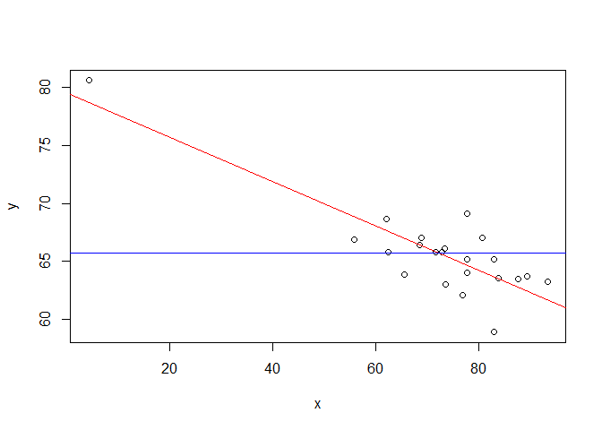

```r
y.bar <- mean(y)
plot(x,y)
abline(model, col="red")
text(30, 220, "Y_duga", adj = c(-0.1, 1.5), col = "red", cex = 0.8)
abline(h=y.bar, col="blue")
text(31, 185, "Y_bar", adj = c(-0.1, 1.5), col = "blue", cex = 0.8)
```

Dari scatter plot di atas, teramati adanya amatan yang menyimpang relatif terhadapn nilai harapannya. Penyimpangan amatan dari nilai harapannya inilah yang disebut sebagai galat. Keragaman dari galat tiap amatan ini dapat diurai berdasarkan garis dugaan persamaan $(\hat{Y})$ dan garis rataan nilai resposnya $(\bar{Y})$. Penguraian keragaman ini dapat dituliskan sebagai Jumlah Kuadrat Regresi (JKR), Jumlah Kuadrat Galat (JKG), dan Jumlah Kuadrat Total (JKT) dengan perhitungan sebagai berikut.

$$JKR=\sum_{i=1}^{n}{(\hat{y_i}-\bar{y})^2};
JKG=\sum_{i=1}^{n}{(y_i-\hat{y})^2};JKT=\sum_{i=1}^{n}{(y_i-\bar{y})^2}$$

Hubungan antara ketiganya dapat pula dituliskan sebagai berikut.

$$JKT=JKR+JKG$$

Nilai penguraian keragaman ini dapat diamati pula menggunakan fungsi `anova` pada bagian **Sum Sq (Jumlah Kuadrat)** seperti yang ditampilkan di bawah. Pada output sintaks di bawah, JKR model bernilai 246.082 dan JKG model bernilai 95.982

```r
(anova.model <- anova(model))
```

```
## Analysis of Variance Table
##
## Response: y
##           Df  Sum Sq Mean Sq F value    Pr(>F)
## x          1 246.082 246.082  51.277 6.179e-07 ***
## Residuals 20  95.982   4.799
## ---
## Signif. codes:  0 '***' 0.001 '**' 0.01 '*' 0.05 '.' 0.1 ' ' 1
```

Dari tabel ANOVA dan penguraian keragaman, dapat diduga pula **ragam galat/error** dari model yang kita peroleh. Secara umum, error dari model dapat diduga oleh nilai Kuadrat Tengah Galat (KTG) sehingga berdasarkan output sintaks di atas, diketahui bahwa ragam galat dari model bernilai 4.799. Hubungan antara keduanya dapat dituliskan sebagai berikut.

$$\hat{\sigma^2}=S_e^2=KTG=\frac{JKG}{(n-2)}$$

```r
(KTG <- anova.model$`Mean Sq`[2])
```

```
## [1] 4.799089
```

Dari nilai dugaan ragam galat di atas, dapat diduga pula nilai dugaan dari simpangan bakunya. Dugaan simpangan baku inilah yang disebut sebagai **galat baku**. Hubungan antara galat baku dan ragam galat dapat dituliskan sebagai berikut.

$$s_e=\sqrt{S_e^2}$$

Oleh karena simpangan baku merupakan akar kuadrat dari ragam, maka nilai dugaan galat baku model yang kita bentuk adalah $S_e=\sqrt{4.799}\approx2.191$

```r
(galat.baku <- sqrt(KTG))
```

```
## [1] 2.190682
```

# Keragaman Dugaan Parameter

## Dugaan Parameter $\beta_0$

Sebelumnya, melalui fungsi `lm` dan perhitungan manual yang sudah dibahas pada pertemuan sebelumnya, kita sudah mendapatkan nilai dugaan parameter $\beta_0$ dan $\beta_1$ sebesar 79.572 dan -0.192. Kedua nilai dugaan parameter tersebut dapat kita definisikan sebagai berikut.

```r
(b0 <- model$coefficients[[1]])
```

```
## [1] 79.57161
```

```r
(b1 <- model$coefficients[[2]])
```

```
## [1] -0.1919921
```

Selanjutnya kita dapat menghitung nilai ragam dan t-hitung dari dugaan parameter $\beta_0$ tersebut dengan perhitungan sebagai berikut.

$$S_\hat{\beta_0}=\sqrt{KTG(\frac{1}{n}+\frac{\bar{x}^2}{\sum_{i=1}^{n}{(x_i-\bar{x})^2}})};t_h=\frac{\hat{\beta_0}-\beta_0}{S_\hat{\beta_0}}$$

Nilai $S_\hat{\beta_0}$ dapat dihitung dengan sintaks sebagai berikut

```r
(se_b0 <- sqrt(KTG*(1/n+mean(x)^2/sum((x-mean(x))^2))))
```

```
## [1] 2.022799
```

Jika dalam uji hipotesis kita ingin menguji apakah $\beta_0=0$, maka nilai $t_h$ dapat dihitung sebagai berikut.

```r
(t_b0 <- b0/se_b0)
```

```
## [1] 39.33739
```

## Dugaan Parameter $\beta_1$

Sementara itu, ragam dan t-hitung dari dugaan parameter $\beta_1$ dapat diperoleh dari perhitungan berikut.

$$S_\hat{\beta_1}=\sqrt{\frac{KTG}{\sum_{i=1}^{n}{(x_i-\bar{x})^2}}};t_h=\frac{\hat{\beta_1}-\beta_1}{S_\hat{\beta_1}}$$

Nilai $S_\hat{\beta_1}$ dapat dihitung dengan sintaks sebagai berikut

```r
(se_b1 <- sqrt(KTG/sum((x-mean(x))^2)))
```

```
## [1] 0.02681162
```

Jika dalam uji hipotesis kita ingin menguji apakah $\beta_1=0$, maka nilai $t_h$ dapat dihitung sebagai berikut.

```r
(t_b1 <- b1/se_b1)
```

```
## [1] -7.160779
```

## Selang Kepercayaan Parameter

Secara umum, kita dapat memahami bahwa selang kepercayaan untuk $\hat{\beta_0}$ dan $\hat{\beta_1}$ terdiri atas batas bawah dan batas atas yang dapat dituliskan sebagai berikut.

$$\hat{\beta_0}-t_{(n-2;\frac{\alpha}{2})}<\hat{\beta_0}<\hat{\beta_0}+t_{(n-2;\frac{\alpha}{2})}$$

$$\hat{\beta_1}-t_{(n-2;\frac{\alpha}{2})}<\hat{\beta_1}<\hat{\beta_1}+t_{(n-2;\frac{\alpha}{2})}$$

Batas bawah untuk kedua dugaan parameter dalam taraf kepercayaan $\alpha=0.05$ dapat dihitung sebagai berikut.

```r
#Batas Bawah beta0
(bb.b0 <- b0 - abs(qt(0.025, df=n-2))*se_b0)
```

```
## [1] 75.16432
```

```r
#Batas Bawah beta1
(bb.b1 <- b1 - abs(qt(0.025, df=n-2))*se_b1)
```

```
## [1] -0.2504096
```

Sementara itu, batas atas untuk kedua dugaan parameter dalam taraf kepercayaan $\alpha=0.05$ dapat dihitung sebagai berikut.

```r
#Batas Atas beta_0
(ba.b0 <- b0 + abs(qt(0.025, df=n-2))*se_b0)
```

```
## [1] 83.97891
```

```r
#Batas Atas beta_1
(ba.b1 <- b1 + abs(qt(0.025, df=n-2))*se_b1)
```

```
## [1] -0.1335746
```

# Selang Kepercayaan

## Bagi Nilai Rataan / Nilai Harapan Amatan

Secara umum, kita dapat memahami bahwa selang kepercayaan untuk $E(\hat{Y}|x_0)$ terdiri atas batas bawah dan batas atas yang dapat dituliskan sebagai berikut.

$$E(\hat{Y}|x_0)\pm
t_{(n-2;\frac{\alpha}{2})}S_e\sqrt{(\frac{1}{n}+\frac{{(x_i-\bar{x})^2}}{{\sum_{i=1}^{n}{(x_i-\bar{x})^2}}})}$$

Misalkan kita ingin menduga nilai rataan (harapan) amatan ketika nilai $x=17$. Kita dapat memanfaatkan fungsi `predict` untuk mendapatkan nilai dugaan dan selang kepercayaannya sebagai berikut.

```r
amatan.diduga <- data.frame(x=17)
predict(model, amatan.diduga, interval = "confidence")
```

```
##        fit      lwr      upr
## 1 76.30775 73.06962 79.54588
```

Berdasarkan output sintaks di atas, diketahui bahwa dugaan rataan nilai $Y$ ketika nilai $x=17$ adalah 76.308. Selain itu, diindikasikan juga bahwa dalam taraf kepercayaan 95%, diyakini bahwa nilai dugaan rataan $Y$ ketika nilai $x=17$ berada dalam selang 73.070 hingga 79.546.

## Bagi Individu Amatan

Secara umum, kita dapat memahami bahwa selang kepercayaan untuk $\hat{y}(s_i)$ terdiri atas batas bawah dan batas atas yang dapat dituliskan sebagai berikut.

$$\hat{y}(x_i)\pm
t_{(n-2;\frac{\alpha}{2})}S_e\sqrt{(1+\frac{1}{n}+\frac{{(x_i-\bar{x})^2}}{{\sum_{i=1}^{n}{(x_i-\bar{x})^2}}})}$$

Misalkan kita ingin menduga nilai individu amatan ketika nilai $x=17$. Kita dapat memanfaatkan fungsi `predict` untuk mendapatkan nilai dugaan dan selang kepercayaannya sebagai berikut.

```r
predict(model, amatan.diduga, interval = "prediction")
```

```
##        fit      lwr      upr
## 1 76.30775 70.70708 81.90842
```

Berdasarkan output sintaks di atas, diketahui bahwa dugaan nilai individu $Y$ ketika nilai $x=17$ adalah 76.308. Selain itu, diindikasikan juga bahwa dalam taraf kepercayaan 95%, diyakini bahwa nilai amatan individu $Y$ ketika nilai $x=17$ berada dalam selang 70.707 hingga 81.908.